# Visualizing Data Distributions in R

Histograms, Bar Plots, and the Logic of Central Tendency

Bogdan G. Popescu

bogdan.popescu@johncabot.edu

John Cabot University

## Using R

## Using R

## Using R

## Using R

## Using R

## Using R

## Using R

## Using R

Press CMD + A or Ctrl + A and then Press Delete

## Using R

## Using R

Then type:

```yaml
---
title: "Notebook"
author: "Your Name"
date: "July 26, 2025"
format:
  html:
    toc: true
    number-sections: true
    colorlinks: true
    smooth-scroll: true
    embed-resources: true
---
```

## Using R

## Using R

## Using R

## Using R

## Using R

## Using R

## Using R

## Using R

## Using R

## Using R

## Using R

## Using R

## Using R

## Using R

## Using R

## Using R

## Using R

## Using R

## Using R

## Using R

## Using R

## Using R

## Using R

## Opening the File

We first remove what we had previously

```r
# Remove all objects from memory
rm(list = ls())
```

## Opening a File

Download the following datasets from Dropbox:

- [Life expectancy data](https://www.dropbox.com/scl/fi/pfyhtd4t5pud7z33q0f1z/life-expectancy.csv?rlkey=hiq1fgfhr7bq7janjd088ymkf&dl=0)
- [Urbanization data](https://www.dropbox.com/scl/fi/oaz9e8eew2j9sronu4628/share-of-population-urban.csv?rlkey=uvouihzy88mpwt6sr7r8tji28&dl=0)

Place them in your working directory or folder.

## Opening the File

To get the file path we simply go to the relevant folder

```r
# This opens a file dialog to select your file
file_path <- file.choose()
file_path
```

## Opening the File

Once we have the path, we can now read the files:

```r
# Defining Paths
file_path <- "/Users/bgpopescu/Library/CloudStorage/Dropbox/john_cabot/teaching/research_workshop/lecture8/data/"
# Use file.path() to construct full path
life_expectancy_df <- read.csv(file.path(file_path, "life-expectancy.csv"))
urbanization_df <- read.csv(file.path(file_path, "share-of-population-urban.csv"))
```

## Doing it

### Calculating Average by Country Code

This is what this looks like in code for `life_expectancy_df2`:

```r
library(dplyr)
life_expectancy_df2 <- life_expectancy_df%>%
  dplyr::group_by(Code)%>%
  dplyr::summarize(life_exp_mean=mean(Life.expectancy.at.birth..historical.))
```

This is what this looks like in code for `urbanization_df2`:

```r
urbanization_df2 <- urbanization_df%>%
  dplyr::group_by(Code)%>%
  dplyr::summarize(urb_mean=mean(Urban.population....of.total.population.))
```

## Cleaning the Data

### Removing Countries with Strange Labels, Left Merge, Removing NA Values

```r
weird_labels <- c("OWID_KOS", "OWID_WRL", "")
clean_life_expectancy_df<-subset(life_expectancy_df2, !(Code %in% weird_labels))
clean_urbanization_df<-subset(urbanization_df2, !(Code %in% weird_labels))
```

We will now perform a left join to combine urbanization data with life expectancy data based on Code.

```r
merged_data <- left_join(clean_life_expectancy_df, clean_urbanization_df, by = c("Code"="Code"))
```

This is how we remove NA values

```r
merged_data2<-subset(na.omit(merged_data))
```

## Histograms

### What Is a Histogram?

A histogram is a type of bar chart that shows the distribution of numerical data.

It breaks the range of values into **intervals (called bins)** and counts how many values fall into each bin.

It helps us answer:

- What does the data look like?
- Where are most values concentrated?

## Histograms

### Example – Student Test Scores

| SAT Score Range | Number of Students |
| --- | --- |
| 400–800 | 1 |
| 800–1200 | 4 |
| 1200–1600 | 5 |
| 1600–2000 | 3 |
| 2000–2400 | 2 |

## Histograms

### Example – Student Test Scores

| SAT Score Range | Number of Students |
| --- | --- |
| 400–800 | 1 |
| 800–1200 | 4 |
| 1200–1600 | 5 |
| 1600–2000 | 3 |
| 2000–2400 | 2 |

[figure not shown]

## Histograms

### Example – Student Test Scores

| SAT Score Range | Number of Students |
| --- | --- |
| 400–800 | 1 |
| 800–1200 | 4 |
| 1200–1600 | 5 |
| 1600–2000 | 3 |
| 2000–2400 | 2 |

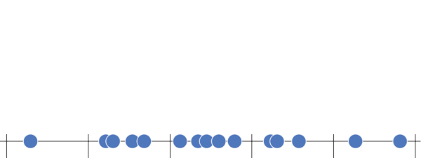

## Histograms

### Example – Student Test Scores

| SAT Score Range | Number of Students |
| --- | --- |
| 400–800 | 1 |
| 800–1200 | 4 |
| 1200–1600 | 5 |
| 1600–2000 | 3 |
| 2000–2400 | 2 |

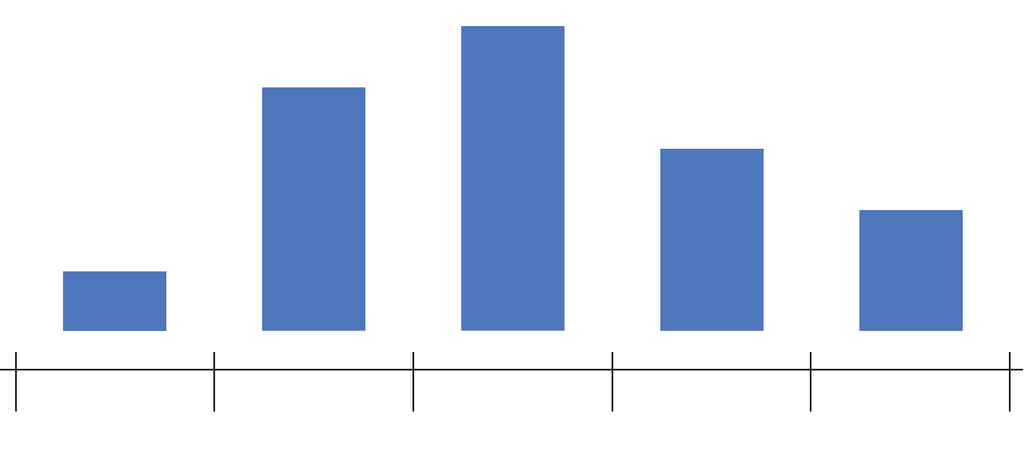

## Creating a Bar Plot from a Frequency Table

### Step1: Rounding the values

```r
#Step1: Rounding the values
merged_data2$life_exp_mean_rounded<-round(merged_data2$life_exp_mean, 0)
merged_data2$urb_mean_rounded<-round(merged_data2$urb_mean, 0)
head(merged_data2, n=5)
```

| Code | life_exp_mean | urb_mean | life_exp_mean_rounded | urb_mean_rounded |
| --- | --- | --- | --- | --- |
| ABW | 70.25972 | 48.05939 | 70 | 48 |
| AFG | 45.38333 | 18.61175 | 45 | 19 |
| AGO | 45.08466 | 37.53970 | 45 | 38 |
| ALB | 68.28611 | 40.44416 | 68 | 40 |
| AND | 77.04861 | 87.04302 | 77 | 87 |

## Creating a Bar Plot from a Frequency Table

### Step2: Creating a frequency table

```r
#Step2: Creating a frequency table
freq_table<-table(merged_data2$life_exp_mean_rounded)
freq_table
```

```
38 43 44 45 46 47 48 49 50 51 52 53 54 55 56 57 58 59 60 61 62 63 64 65 66 67
 1  2  3  4  4  5  5  2  2  4 11  6  5  6  4  5  6  6 10 10  6  6 12 11  5 11
68 69 70 71 72 73 74 75 77
 9 11 12 12  4  4  1  6  3
```

```r
#Step3: Turning the table into a dataframe
freq_table<-data.frame(freq_table)
```

```r
#Step4: Inspecting the names
names(freq_table)
```

```
[1] "Var1" "Freq"
```

## Creating a Bar Plot from a Frequency Table

### Step2: Creating a frequency table

```r
#Step5: Providing more intuitive names
names(freq_table)[1]<-"life_exp_mean_rounded"
names(freq_table)[2]<-"frequency"
#Step6: Turning factor variables into numeric
freq_table$life_exp_mean_rounded<-as.numeric(as.character(freq_table$life_exp_mean_rounded))
```

```r
str(freq_table)
```

```
'data.frame':   35 obs. of  2 variables:
 $ life_exp_mean_rounded: num  38 43 44 45 46 47 48 49 50 51 ...
 $ frequency            : int  1 2 3 4 4 5 5 2 2 4 ...
```

```r
names(freq_table)
```

```
[1] "life_exp_mean_rounded" "frequency"
```

## Creating a Bar Plot from a Frequency Table

### Step2: Creating a frequency table

Inspecting the new dataframe

```r
freq_table
```

| life_exp_mean_rounded | frequency |
| --- | --- |
| 38 | 1 |
| 43 | 2 |
| 44 | 3 |
| 45 | 4 |
| 46 | 4 |
| 47 | 5 |
| 48 | 5 |
| 49 | 2 |
| 50 | 2 |
| 51 | 4 |

[output cut: 25 more lines]

## Creating a Bar Plot from a Frequency Table

### Step3: Creating the Barplot

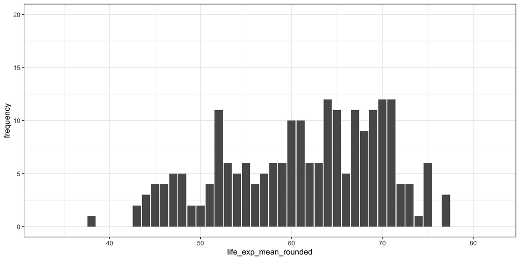

```r
library(ggplot2)
#Step7: Creating the barplot
fig5<-ggplot(data = freq_table, aes(x=life_exp_mean_rounded, y=frequency))+
  geom_bar(stat="identity")+
  theme_bw()+
  coord_cartesian(xlim = c(min(merged_data2$life_exp_mean)-5,
                    max(merged_data2$life_exp_mean)+5),
           ylim = c(0, 20))
fig5
```

## Creating a Bar Plot from a Frequency Table

### Step4: Creating a Histogram using `geom_histogram`

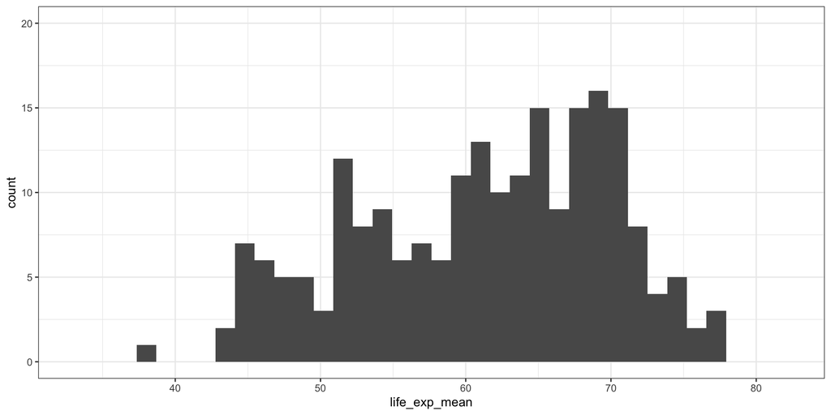

```r
fig5_b<-ggplot(data = merged_data2, aes(x=life_exp_mean))+
  geom_histogram()+
  theme_bw()+
    coord_cartesian(xlim = c(min(merged_data2$life_exp_mean)-5,
                    max(merged_data2$life_exp_mean)+5),
           ylim = c(0, 20))
fig5_b
```

## Creating a Bar Plot from a Frequency Table

### Step4: Creating a Histogram using `geom_histogram`

This is how we can control the bin size: 50

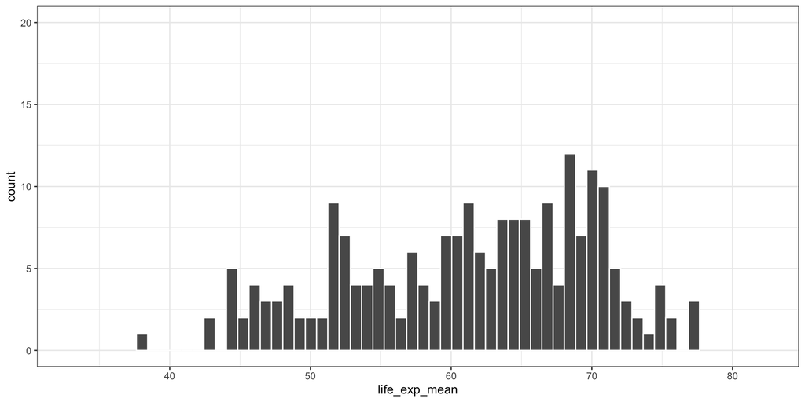

```r
fig5_b<-ggplot(data = merged_data2, aes(x=life_exp_mean))+
  geom_histogram(bins = 50, col="white")+
  theme_bw()+
    coord_cartesian(xlim = c(min(merged_data2$life_exp_mean)-5,
                    max(merged_data2$life_exp_mean)+5),
           ylim = c(0, 20))
fig5_b
```

## Creating a Bar Plot from a Frequency Table

### Step4: Creating a Histogram using `geom_histogram`

This is how we can control the bin size: 35

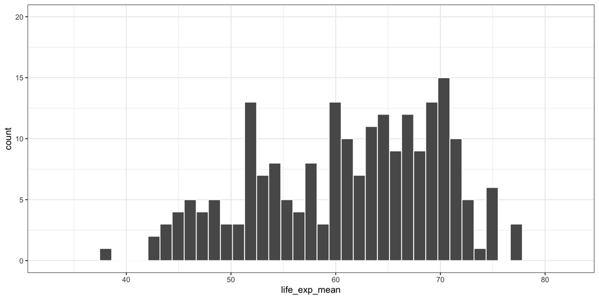

```r
fig5_b<-ggplot(data = merged_data2, aes(x=life_exp_mean))+
  geom_histogram(bins = 35, col="white")+
  theme_bw()+
    coord_cartesian(xlim = c(min(merged_data2$life_exp_mean)-5,
                    max(merged_data2$life_exp_mean)+5),
           ylim = c(0, 20))
fig5_b
```

## Creating a Bar Plot from a Frequency Table

This is how we put them side by side

```r
library(gridExtra)
grid.arrange(fig5, fig5_b, ncol=2)
```

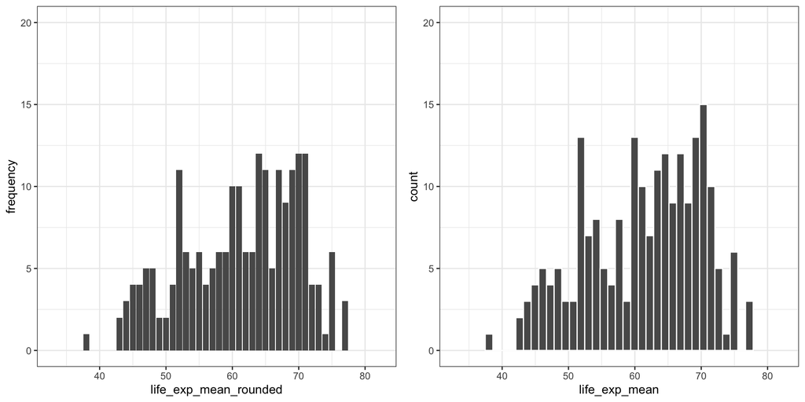

## Mapping the Measures of Central Tendency

### Calculating Mean

- The **mean** describes the average value of a variable.
- It is calculated as:

$$\bar{x} = \frac{x_1 + x_2 + \dots + x_n}{n} = \frac{\sum x_i}{n}$$

## Mapping the Measures of Central Tendency

### Calculating Mean

In your case, we can calculate the mean for all the values in life expectancy

```r
# Calculate the mean
life_exp_mean <- mean(merged_data2$life_exp_mean, na.rm = TRUE)
life_exp_mean
```

```
[1] 61.26972
```

```r
mean_label <- paste("Mean (x̄):\n", round(life_exp_mean, 2))
y_coord<-17
fig5_b<-ggplot(data = merged_data2, aes(x=life_exp_mean))+
  geom_histogram(bins = 35, col="white")+
  geom_vline(xintercept=life_exp_mean, linetype='dashed', col = 'red')+
  annotate(geom="text",
           x=life_exp_mean-2,
           y=y_coord,
           label=mean_label,
           color="red")+
  theme_bw()+
    coord_cartesian(xlim = c(min(merged_data2$life_exp_mean)-5,
                    max(merged_data2$life_exp_mean)+5),
           ylim = c(0, 20))
fig5_b
```

## Mapping the Measures of Central Tendency

### Calculating Mean

In your case, we can calculate the mean for all the values in life expectancy

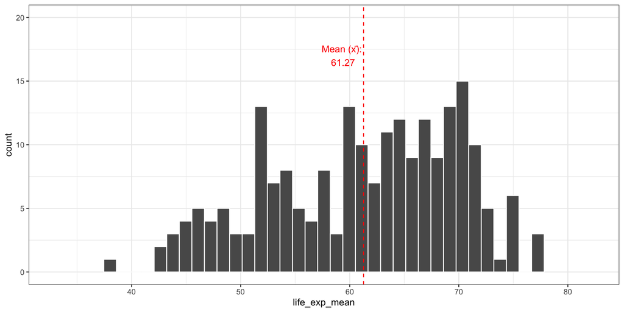

## Mapping the Measures of Central Tendency

### Central Tendency: Median

In your case, we can calculate the median for all the values in life expectancy

```r
# Calculate the mean
life_exp_median <- median(merged_data2$life_exp_mean)
life_exp_median
```

```
[1] 62.57153
```

```r
mean_label <- paste("Mean (x̄):\n", round(life_exp_mean, 2))
median_label <- paste("Median:\n", round(life_exp_median, 2))
y_coord<-17
fig5_b <- ggplot(data = merged_data2, aes(x = life_exp_mean)) +
  geom_histogram(bins = 35, col = "white") +
  geom_vline(xintercept = life_exp_mean, linetype = "dashed", color = "red") +
  geom_vline(xintercept = life_exp_median, linetype = "dashed", color = "blue") +
  annotate("text", x = life_exp_mean - 2, y = y_coord, label = mean_label, color = "red") +
  annotate("text", x = life_exp_median + 2, y = y_coord, label = median_label, color = "blue") +
  theme_bw()+
    coord_cartesian(xlim = c(min(merged_data2$life_exp_mean)-5,
                    max(merged_data2$life_exp_mean)+5),
           ylim = c(0, 20))
fig5_b
```

## Mapping the Measures of Central Tendency

### Central Tendency: Median

In your case, we can calculate the median for all the values in life expectancy

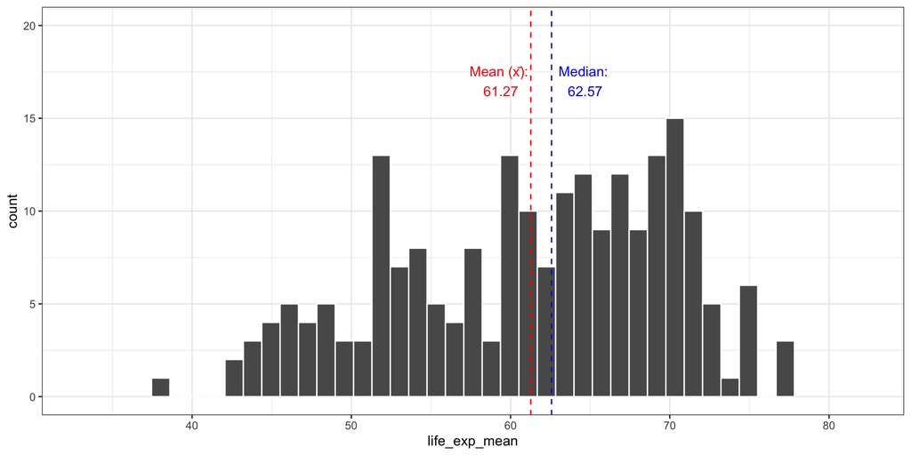

## Mapping the Measures of Central Tendency

### Central Tendency: Median and Boxplot

Another way to do this is through a boxplot

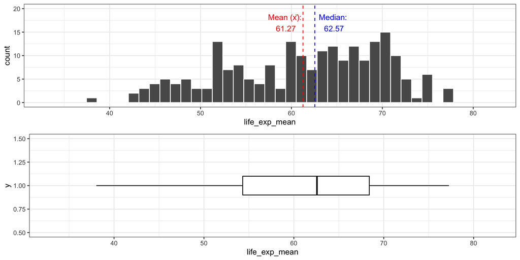

## Mapping the Measures of Central Tendency

### Central Tendency: Median and Boxplot

Another way to do this is through a boxplot

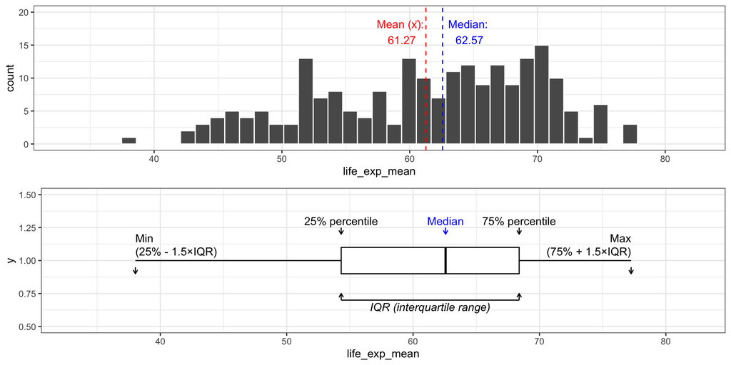

## Measures of Dispersion

### Common Measures

- **Standard Deviation**:
  $$s = \sqrt{s^2}$$
  (Gives average distance from the mean)

## Mapping the Measures of Dispersion

### Standard Deviation

```r
# Calculating sd
life_exp_sd <- sd(merged_data2$life_exp_mean)
# Create sequence for axis ticks
sigma_breaks <- life_exp_mean + (-3:3) * life_exp_sd
# Replacing the x-ticks with the SD
sigma_labels <- c("-3s", "-2s", "-1s", "x̄", "+1s", "+2s", "+3s")
```

## Mapping the Measures of Dispersion

### Standard Deviation

This is how we create the graph.

```r
median_label <- paste("Median:\n", round(life_exp_median, 2))
y_coord<-17
# Histogram with SD-based axis
fig5_b <- ggplot(data = merged_data2, aes(x = life_exp_mean)) +
  geom_histogram(bins = 35, col = "white") +
  geom_vline(xintercept = life_exp_mean, linetype = "dashed", color = "red") +
#  geom_vline(xintercept = median(life_expectancy_df$Life.expectancy.at.birth..historical., na.rm = TRUE), linetype = "dashed", color = "blue") +
  annotate("text", x = life_exp_mean - 2, y = y_coord, label = mean_label, color = "red") +
#  annotate("text", x = life_exp_median + 2, y = y_coord, label = median_label, color = "blue") +
  scale_x_continuous(breaks = sigma_breaks, labels = sigma_labels) +
  theme_bw()+
    coord_cartesian(xlim = c(min(merged_data2$life_exp_mean)-5,
                    max(merged_data2$life_exp_mean)+5),
           ylim = c(0, 20))

fig5_b
```

## Mapping the Measures of Dispersion

### Standard Deviation

This is how we can visualize the standard deviations.

[figure not shown]

## Conclusion

- **Histograms** show the shape of a continuous variable’s distribution
- **Bar plots** visualize frequencies of discrete or grouped values
- **Mean** and **median** describe central tendency
- A big gap between them often signals **skew**
- **Standard deviation** shows how spread out the values are